# Gather 收集

```python
import numpy as np
import pandas as pd
import requests
import os
import re
import json
```

```python
df=pd.read_csv('twitter-archive-enhanced.csv')
```

```python
tweet_list=[]

with open("tweet_json.txt", 'r') as f:
    for line in f.readlines():
        dic = json.loads(line)
        tweet_list.append({'id':dic['id'],'fav_count': dic[ "favorite_count"], 'retweet_count':dic["retweet_count"]})

tweet_df = pd.DataFrame(tweet_list, columns = ['id', 'fav_count', 'retweet_count'])

tweet_df.to_csv('tweet_count.csv', index=False)
```

```python
url='https://raw.githubusercontent.com/udacity/new-dand-advanced-china/master/%E6%95%B0%E6%8D%AE%E6%B8%85%E6%B4%97/WeRateDogs%E9%A1%B9%E7%9B%AE/image-predictions.tsv'
response = requests.get(url)
#print(response)
with open(url.split('/')[-1],mode='wb') as file:
    file.write(response.content)

image_df=pd.read_csv('image-predictions.tsv',sep='\t')
```

# Assess 评估

```python
df.head()
```

|  | tweet_id | in_reply_to_status_id | in_reply_to_user_id | timestamp | source | text | retweeted_status_id | retweeted_status_user_id | retweeted_status_timestamp | expanded_urls | rating_numerator | rating_denominator | name | doggo | floofer | pupper | puppo |
| --- | --- | --- | --- | --- | --- | --- | --- | --- | --- | --- | --- | --- | --- | --- | --- | --- | --- |
| 0 | 892420643555336193 | NaN | NaN | 2017-08-01 16:23:56 +0000 | <a href="http://twitter.com/download/iphone" r... | This is Phineas. He's a mystical boy. Only eve... | NaN | NaN | NaN | https://twitter.com/dog_rates/status/892420643... | 13 | 10 | Phineas | None | None | None | None |
| 1 | 892177421306343426 | NaN | NaN | 2017-08-01 00:17:27 +0000 | <a href="http://twitter.com/download/iphone" r... | This is Tilly. She's just checking pup on you.... | NaN | NaN | NaN | https://twitter.com/dog_rates/status/892177421... | 13 | 10 | Tilly | None | None | None | None |
| 2 | 891815181378084864 | NaN | NaN | 2017-07-31 00:18:03 +0000 | <a href="http://twitter.com/download/iphone" r... | This is Archie. He is a rare Norwegian Pouncin... | NaN | NaN | NaN | https://twitter.com/dog_rates/status/891815181... | 12 | 10 | Archie | None | None | None | None |
| 3 | 891689557279858688 | NaN | NaN | 2017-07-30 15:58:51 +0000 | <a href="http://twitter.com/download/iphone" r... | This is Darla. She commenced a snooze mid meal... | NaN | NaN | NaN | https://twitter.com/dog_rates/status/891689557... | 13 | 10 | Darla | None | None | None | None |
| 4 | 891327558926688256 | NaN | NaN | 2017-07-29 16:00:24 +0000 | <a href="http://twitter.com/download/iphone" r... | This is Franklin. He would like you to stop ca... | NaN | NaN | NaN | https://twitter.com/dog_rates/status/891327558... | 12 | 10 | Franklin | None | None | None | None |

```python
tweet_df.head()
```

|  | id | fav_count | retweet_count |
| --- | --- | --- | --- |
| 0 | 892420643555336193 | 39492 | 8842 |
| 1 | 892177421306343426 | 33786 | 6480 |
| 2 | 891815181378084864 | 25445 | 4301 |
| 3 | 891689557279858688 | 42863 | 8925 |
| 4 | 891327558926688256 | 41016 | 9721 |

```python
image_df.head()
```

|  | tweet_id | jpg_url | img_num | p1 | p1_conf | p1_dog | p2 | p2_conf | p2_dog | p3 | p3_conf | p3_dog |
| --- | --- | --- | --- | --- | --- | --- | --- | --- | --- | --- | --- | --- |
| 0 | 666020888022790149 | https://pbs.twimg.com/media/CT4udn0WwAA0aMy.jpg | 1 | Welsh_springer_spaniel | 0.465074 | True | collie | 0.156665 | True | Shetland_sheepdog | 0.061428 | True |
| 1 | 666029285002620928 | https://pbs.twimg.com/media/CT42GRgUYAA5iDo.jpg | 1 | redbone | 0.506826 | True | miniature_pinscher | 0.074192 | True | Rhodesian_ridgeback | 0.072010 | True |
| 2 | 666033412701032449 | https://pbs.twimg.com/media/CT4521TWwAEvMyu.jpg | 1 | German_shepherd | 0.596461 | True | malinois | 0.138584 | True | bloodhound | 0.116197 | True |
| 3 | 666044226329800704 | https://pbs.twimg.com/media/CT5Dr8HUEAA-lEu.jpg | 1 | Rhodesian_ridgeback | 0.408143 | True | redbone | 0.360687 | True | miniature_pinscher | 0.222752 | True |
| 4 | 666049248165822465 | https://pbs.twimg.com/media/CT5IQmsXIAAKY4A.jpg | 1 | miniature_pinscher | 0.560311 | True | Rottweiler | 0.243682 | True | Doberman | 0.154629 | True |

```python
df.info()
```

```
<class 'pandas.core.frame.DataFrame'>
RangeIndex: 2356 entries, 0 to 2355
Data columns (total 17 columns):
tweet_id                      2356 non-null int64
in_reply_to_status_id         78 non-null float64
in_reply_to_user_id           78 non-null float64
timestamp                     2356 non-null object
source                        2356 non-null object
text                          2356 non-null object
retweeted_status_id           181 non-null float64
retweeted_status_user_id      181 non-null float64
retweeted_status_timestamp    181 non-null object
expanded_urls                 2297 non-null object
rating_numerator              2356 non-null int64
rating_denominator            2356 non-null int64
name                          2356 non-null object
doggo                         2356 non-null object
floofer                       2356 non-null object
pupper                        2356 non-null object
puppo                         2356 non-null object
dtypes: float64(4), int64(3), object(10)
memory usage: 313.0+ KB
```

```python
tweet_df.info()
```

```
<class 'pandas.core.frame.DataFrame'>
RangeIndex: 2352 entries, 0 to 2351
Data columns (total 3 columns):
id               2352 non-null int64
fav_count        2352 non-null int64
retweet_count    2352 non-null int64
dtypes: int64(3)
memory usage: 55.2 KB
```

```python
image_df.info()
```

```
<class 'pandas.core.frame.DataFrame'>
RangeIndex: 2075 entries, 0 to 2074
Data columns (total 12 columns):
tweet_id    2075 non-null int64
jpg_url     2075 non-null object
img_num     2075 non-null int64
p1          2075 non-null object
p1_conf     2075 non-null float64
p1_dog      2075 non-null bool
p2          2075 non-null object
p2_conf     2075 non-null float64
p2_dog      2075 non-null bool
p3          2075 non-null object
p3_conf     2075 non-null float64
p3_dog      2075 non-null bool
dtypes: bool(3), float64(3), int64(2), object(4)
memory usage: 152.1+ KB
```

```python
# 检查姓名
df.name.value_counts()
```

```
None        745
a            55
Charlie      12
Oliver       11
Cooper       11
Lucy         11
Tucker       10
Penny        10
Lola         10
Winston       9
Bo            9
the           8
Sadie         8
an            7
Daisy         7
Toby          7
Bailey        7
Buddy         7
Dave          6
Oscar         6
Scout         6
Jax           6
Koda          6
Jack          6
Stanley       6
Rusty         6
Leo           6
Bella         6
Milo          6
Sammy         5
           ...
Trevith       1
Wishes        1
Bluebert      1
Jimbo         1
Tilly         1
Geoff         1
Tove          1
Pilot         1
Karma         1
Henry         1
Dobby         1
Ridley        1
Eazy          1
Deacon        1
Jonah         1
Chef          1
Staniel       1
Al            1
Sephie        1
Aldrick       1
Zoe           1
Kaia          1
Antony        1
Harrison      1
Pawnd         1
Tycho         1
Monkey        1
Millie        1
Gòrdón        1
Mabel         1
Name: name, Length: 957, dtype: int64
```

```python
#检查评分的分子
df.rating_numerator.value_counts()
```

```
12      558
11      464
10      461
13      351
9       158
8       102
7        55
14       54
5        37
6        32
3        19
4        17
1         9
2         9
420       2
```

[output cut: 26 more lines]

```python
#检查分母
df.rating_denominator.value_counts()
```

```
10     2333
11        3
50        3
80        2
20        2
2         1
16        1
40        1
70        1
15        1
90        1
110       1
120       1
130       1
150       1
170       1
7         1
0         1
Name: rating_denominator, dtype: int64
```

```python
#提取一个分子、分母大于10的数据行进行查看
df.text[902]
```

```
'Why does this never happen at my front door... 165/150 https://t.co/HmwrdfEfUE'
```

```python
# 查看一个评分分母为0的text
print(df.query('rating_denominator==0').text[313])
```

```
@jonnysun @Lin_Manuel ok jomny I know you're excited but 960/00 isn't a valid rating, 13/10 is tho
```

```python
type(df.timestamp[0])
```

```
str
```

```python
sum(df.tweet_id.duplicated())
```

```
0
```

```python
print(df.query('retweeted_status_id != "NaN"').text)
```

```
19      RT @dog_rates: This is Canela. She attempted s...
32      RT @Athletics: 12/10 #BATP https://t.co/WxwJmv...
36      RT @dog_rates: This is Lilly. She just paralle...
68      RT @dog_rates: This is Emmy. She was adopted t...
73      RT @dog_rates: Meet Shadow. In an attempt to r...
74      RT @dog_rates: Meet Terrance. He's being yelle...
78      RT @rachel2195: @dog_rates the boyfriend and h...
91      RT @dog_rates: This is Coco. At first I though...
95      RT @dog_rates: This is Walter. He won't start ...
97      RT @dog_rates: This is Sierra. She's one preci...
101     RT @loganamnosis: Penelope here is doing me qu...
109     RT @dog_rates: This is Dawn. She's just checki...
118     RT @dog_rates: We only rate dogs. This is quit...
124     RT @dog_rates: Say hello to Cooper. His expres...
130     RT @rachaeleasler: these @dog_rates hats are 1...
```

[output cut: 47 more lines]

```python
# 检查一个reply text
print(df.query('in_reply_to_user_id != "NaN"').text[55])
```

```
@roushfenway These are good dogs but 17/10 is an emotional impulse rating. More like 13/10s
```

```python
df.source.value_counts()
```

```
<a href="http://twitter.com/download/iphone" rel="nofollow">Twitter for iPhone</a>     2221
<a href="http://vine.co" rel="nofollow">Vine - Make a Scene</a>                          91
<a href="http://twitter.com" rel="nofollow">Twitter Web Client</a>                       33
<a href="https://about.twitter.com/products/tweetdeck" rel="nofollow">TweetDeck</a>      11
Name: source, dtype: int64
```

```python
df.doggo.value_counts()
```

```
None     2259
doggo      97
Name: doggo, dtype: int64
```

```python
df.pupper.value_counts()
```

```
None      2099
pupper     257
Name: pupper, dtype: int64
```

```python
df.floofer.value_counts()
```

```
None       2346
floofer      10
Name: floofer, dtype: int64
```

```python
df.puppo.value_counts()
```

```
None     2326
puppo      30
Name: puppo, dtype: int64
```

```python
df[df.tweet_id==777641927919427584]
```

|  | tweet_id | in_reply_to_status_id | in_reply_to_user_id | timestamp | source | text | retweeted_status_id | retweeted_status_user_id | retweeted_status_timestamp | expanded_urls | rating_numerator | rating_denominator | name | doggo | floofer | pupper | puppo |
| --- | --- | --- | --- | --- | --- | --- | --- | --- | --- | --- | --- | --- | --- | --- | --- | --- | --- |
| 767 | 777641927919427584 | NaN | NaN | 2016-09-18 22:54:18 +0000 | <a href="http://twitter.com/download/iphone" r... | RT @dog_rates: This is Arnie. He's a Nova Scot... | 7.504293e+17 | 4.196984e+09 | 2016-07-05 20:41:01 +0000 | https://twitter.com/dog_rates/status/750429297... | 12 | 10 | Arnie | None | None | None | None |

```python
print(df.text[767])
```

```
RT @dog_rates: This is Arnie. He's a Nova Scotian Fridge Floof. Rare af. 12/10 https://t.co/lprdOylVpS
```

```python
sum(df.expanded_urls.duplicated())
```

```
137
```

```python
print(sum(image_df.tweet_id.duplicated()))
print(sum(image_df.jpg_url.duplicated()))
```

```
0
66
```

```python
image_df.img_num.value_counts()
```

```
1    1780
2     198
3      66
4      31
Name: img_num, dtype: int64
```

```python
sum(tweet_df.id.duplicated())
```

```
0
```

```python
tweet_df.fav_count.value_counts()
```

```
0        177
1753       3
3548       3
689        3
1526       3
520        3
465        3
171        3
3508       3
343        3
2417       3
3217       2
3846       2
1501       2
2452       2
```

[output cut: 47 more lines]

## 整洁度

### df表格

- doggo/floofer/pupper/puppo分类不应分为4列，而应归为一列stage

### image_df表格

- 只需要与img_num相关的预测值，其他列可以清除
- 可以根据tweet id与df合并

### tweet_df表格

- 可以根据tweet id与df合并

# Clean 清洗

## 整洁度

### 合并3个dataframe

#### *Define*

根据tweet id合并3个dataframe，将合并后的数据集命名为df_clean，不破坏原数据表。

#### *Code*

```python
# 合并3个表格
df_clean=pd.DataFrame()
df_clean=pd.merge(df,tweet_df,how='left',left_on='tweet_id',right_on='id')
df_clean=pd.merge(df_clean, image_df, how='left',on='tweet_id')
```

#### *Test*

```python
df_clean.info()
```

```
<class 'pandas.core.frame.DataFrame'>
Int64Index: 2356 entries, 0 to 2355
Data columns (total 31 columns):
tweet_id                      2356 non-null int64
in_reply_to_status_id         78 non-null float64
in_reply_to_user_id           78 non-null float64
timestamp                     2356 non-null object
source                        2356 non-null object
text                          2356 non-null object
retweeted_status_id           181 non-null float64
retweeted_status_user_id      181 non-null float64
retweeted_status_timestamp    181 non-null object
expanded_urls                 2297 non-null object
rating_numerator              2356 non-null int64
rating_denominator            2356 non-null int64
name                          2356 non-null object
doggo                         2356 non-null object
floofer                       2356 non-null object
pupper                        2356 non-null object
puppo                         2356 non-null object
id                            2352 non-null float64
fav_count                     2352 non-null float64
retweet_count                 2352 non-null float64
jpg_url                       2075 non-null object
img_num                       2075 non-null float64
p1                            2075 non-null object
p1_conf                       2075 non-null float64
p1_dog                        2075 non-null object
p2                            2075 non-null object
p2_conf                       2075 non-null float64
p2_dog                        2075 non-null object
p3                            2075 non-null object
p3_conf                       2075 non-null float64
p3_dog                        2075 non-null object
dtypes: float64(11), int64(3), object(17)
memory usage: 589.0+ KB
```

```python
df_clean.sample(1)
```

|  | tweet_id | in_reply_to_status_id | in_reply_to_user_id | timestamp | source | text | retweeted_status_id | retweeted_status_user_id | retweeted_status_timestamp | expanded_urls | ... | img_num | p1 | p1_conf | p1_dog | p2 | p2_conf | p2_dog | p3 | p3_conf | p3_dog |
| --- | --- | --- | --- | --- | --- | --- | --- | --- | --- | --- | --- | --- | --- | --- | --- | --- | --- | --- | --- | --- | --- |
| 2083 | 670811965569282048 | NaN | NaN | 2015-11-29 03:50:10 +0000 | <a href="http://twitter.com/download/iphone" r... | Meet Maggie. She enjoys her stick in the yard.... | NaN | NaN | NaN | https://twitter.com/dog_rates/status/670811965... | ... | 1.0 | basset | 0.99409 | True | Walker_hound | 0.003973 | True | beagle | 0.001406 | True |

1 rows × 31 columns

## 质量

### 缺失数据

#### *Define*

- 删除没有图片的行，即jpg_url为空的行
- 删除属于转发消息的行，即retweeted_status_id不为空的行

#### *Code*

```python
# 删除没有图片的行
df_clean=df_clean.dropna(subset=['jpg_url'])
```

```python
# 删除属于转发的行

df_clean=df_clean.query('retweeted_status_id=="NaN"')
```

```python
# 删除清理后的无用字段
df_clean.drop(['id','retweeted_status_id','retweeted_status_user_id','retweeted_status_timestamp'],axis=1,inplace=True)
```

#### *Test*

```python
df_clean.info()
```

```
<class 'pandas.core.frame.DataFrame'>
Int64Index: 1994 entries, 0 to 2355
Data columns (total 27 columns):
tweet_id                 1994 non-null int64
in_reply_to_status_id    23 non-null float64
in_reply_to_user_id      23 non-null float64
timestamp                1994 non-null object
source                   1994 non-null object
text                     1994 non-null object
expanded_urls            1994 non-null object
rating_numerator         1994 non-null int64
rating_denominator       1994 non-null int64
name                     1994 non-null object
doggo                    1994 non-null object
floofer                  1994 non-null object
pupper                   1994 non-null object
puppo                    1994 non-null object
fav_count                1994 non-null float64
retweet_count            1994 non-null float64
jpg_url                  1994 non-null object
img_num                  1994 non-null float64
p1                       1994 non-null object
p1_conf                  1994 non-null float64
p1_dog                   1994 non-null object
p2                       1994 non-null object
p2_conf                  1994 non-null float64
p2_dog                   1994 non-null object
p3                       1994 non-null object
p3_conf                  1994 non-null float64
p3_dog                   1994 non-null object
dtypes: float64(8), int64(3), object(16)
memory usage: 436.2+ KB
```

#### *Define*

reply数据仅剩23行，选取这些行，手动检查是否有必要删除

#### *Code*

```python
df_clean.query('in_reply_to_user_id!="NaN"').text
```

```
149     Ladies and gentlemen... I found Pipsy. He may ...
184     THIS IS CHARLIE, MARK. HE DID JUST WANT TO SAY...
251     PUPDATE: I'm proud to announce that Toby is 23...
565     Like doggo, like pupper version 2. Both 11/10 ...
1016    PUPDATE: can't see any. Even if I could, I cou...
1018    Guys... Dog Jesus 2.0\n13/10 buoyant af https:...
1127    "Challenge completed" \n(pupgraded to 12/10) h...
1330    Seriously, add us 🐶 11/10 for sad wet pupper h...
1339    I found a forest Pipsy. 12/10 https://t.co/mIQ...
1356    Really guys? Again? I know this is a rare Alba...
1452    If you are aware of who is making these please...
1464    This pupper only appears through the hole of a...
1501    These are some pictures of Teddy that further ...
1630    After watching this video, we've determined th...
1634    Two sneaky puppers were not initially seen, mo...
1842    &amp; this is Yoshi. Another world record cont...
1852    We've got ourselves a battle here. Watch out R...
1866    Yea I lied. Here's more. All 13/10 https://t.c...
1882    Ok last one of these. I may try to make some m...
1885    I have found another. 13/10 https://t.co/HwroP...
1892    Just received another perfect photo of dogs an...
2036    I'm just going to leave this one here as well....
2169    This is Tessa. She is also very pleased after ...
Name: text, dtype: object
```

```python
print(df_clean.text[149])
print(df_clean.text[184])
print(df_clean.text[251])
print(df_clean.text[565])
print(df_clean.text[1016])
print(df_clean.text[1018])
print(df_clean.text[1892])
print(df_clean.text[1330])
```

```
Ladies and gentlemen... I found Pipsy. He may have changed his name to Pablo, but he never changed his love for the sea. Pupgraded to 14/10 https://t.co/lVU5GyNFen
THIS IS CHARLIE, MARK. HE DID JUST WANT TO SAY HI AFTER ALL. PUPGRADED TO A 14/10. WOULD BE AN HONOR TO FLY WITH https://t.co/p1hBHCmWnA
PUPDATE: I'm proud to announce that Toby is 236 days sober. Pupgraded to a 13/10. We're all very proud of you, Toby https://t.co/a5OaJeRl9B
Like doggo, like pupper version 2. Both 11/10 https://t.co/9IxWAXFqze
PUPDATE: can't see any. Even if I could, I couldn't reach them to pet. 0/10 much disappointment https://t.co/c7WXaB2nqX
Guys... Dog Jesus 2.0
13/10 buoyant af https://t.co/CuNA7OwfKQ
Just received another perfect photo of dogs and the sunset. 12/10 https://t.co/9YmNcxA2Cc
Seriously, add us 🐶 11/10 for sad wet pupper https://t.co/xwPE9faVZR
```

**随机选取后，根据链接查看tweeter原文，发现大部分是对原po中狗狗评级的修改。为避免一只狗有多行数据，删除reply相关的行**

```python
df_clean=df_clean.query('in_reply_to_user_id=="NaN"')
```

```python
#清除in_reply_to_status_id、in_reply_to_user_id列
df_clean.drop(['in_reply_to_status_id','in_reply_to_user_id'],axis=1,inplace=True)
```

#### *Test*

```python
df_clean.info()
```

```
<class 'pandas.core.frame.DataFrame'>
Int64Index: 1971 entries, 0 to 2355
Data columns (total 25 columns):
tweet_id              1971 non-null int64
timestamp             1971 non-null object
source                1971 non-null object
text                  1971 non-null object
expanded_urls         1971 non-null object
rating_numerator      1971 non-null int64
rating_denominator    1971 non-null int64
name                  1971 non-null object
doggo                 1971 non-null object
floofer               1971 non-null object
pupper                1971 non-null object
puppo                 1971 non-null object
fav_count             1971 non-null float64
retweet_count         1971 non-null float64
jpg_url               1971 non-null object
img_num               1971 non-null float64
p1                    1971 non-null object
p1_conf               1971 non-null float64
p1_dog                1971 non-null object
p2                    1971 non-null object
p2_conf               1971 non-null float64
p2_dog                1971 non-null object
p3                    1971 non-null object
p3_conf               1971 non-null float64
p3_dog                1971 non-null object
dtypes: float64(6), int64(3), object(16)
memory usage: 400.4+ KB
```

## 整洁度

### 根据img_num选取预测值，doggo/floofer/pupper/puppo四列归为一列

#### *Define*

根据img_num来选择相应的预测值，若img_num为4，则赋空值

#### *Code*

```python
breed=[]
conf=[]
pre_dog=[]

def prediction(dataframe):
    if dataframe['img_num']==1:
        breed.append(dataframe['p1'])
        conf.append(dataframe['p1_conf'])
        pre_dog.append(dataframe['p1_dog'])
    elif dataframe['img_num']==2:
        breed.append(dataframe['p2'])
        conf.append(dataframe['p2_conf'])
        pre_dog.append(dataframe['p2_dog'])
    elif dataframe['img_num']==3:
        breed.append(dataframe['p3'])
        conf.append(dataframe['p3_conf'])
        pre_dog.append(dataframe['p3_dog'])
    else:
        breed.append("NaN")
        conf.append("NaN")
        pre_dog.append("NaN")

df_clean.apply(prediction, axis=1)
```

[output not shown]

[output cut: 47 more lines]

```python
# 将breed...补充进dataframe
df_clean['breed']=breed
df_clean['conf']=conf
df_clean['pre_dog']=pre_dog
```

```python
# 删除img_num至p3_dog列
df_clean.drop(['img_num','p1','p1_conf','p1_dog','p2','p2_conf','p2_dog','p3','p3_conf','p3_dog'],axis=1,inplace=True)
```

#### *Test*

```python
df_clean.head()
```

|  | tweet_id | timestamp | source | text | expanded_urls | rating_numerator | rating_denominator | name | doggo | floofer | pupper | puppo | fav_count | retweet_count | jpg_url | breed | conf | pre_dog |
| --- | --- | --- | --- | --- | --- | --- | --- | --- | --- | --- | --- | --- | --- | --- | --- | --- | --- | --- |
| 0 | 892420643555336193 | 2017-08-01 16:23:56 +0000 | <a href="http://twitter.com/download/iphone" r... | This is Phineas. He's a mystical boy. Only eve... | https://twitter.com/dog_rates/status/892420643... | 13 | 10 | Phineas | None | None | None | None | 39492.0 | 8842.0 | https://pbs.twimg.com/media/DGKD1-bXoAAIAUK.jpg | orange | 0.0970486 | False |
| 1 | 892177421306343426 | 2017-08-01 00:17:27 +0000 | <a href="http://twitter.com/download/iphone" r... | This is Tilly. She's just checking pup on you.... | https://twitter.com/dog_rates/status/892177421... | 13 | 10 | Tilly | None | None | None | None | 33786.0 | 6480.0 | https://pbs.twimg.com/media/DGGmoV4XsAAUL6n.jpg | Chihuahua | 0.323581 | True |
| 2 | 891815181378084864 | 2017-07-31 00:18:03 +0000 | <a href="http://twitter.com/download/iphone" r... | This is Archie. He is a rare Norwegian Pouncin... | https://twitter.com/dog_rates/status/891815181... | 12 | 10 | Archie | None | None | None | None | 25445.0 | 4301.0 | https://pbs.twimg.com/media/DGBdLU1WsAANxJ9.jpg | Chihuahua | 0.716012 | True |
| 3 | 891689557279858688 | 2017-07-30 15:58:51 +0000 | <a href="http://twitter.com/download/iphone" r... | This is Darla. She commenced a snooze mid meal... | https://twitter.com/dog_rates/status/891689557... | 13 | 10 | Darla | None | None | None | None | 42863.0 | 8925.0 | https://pbs.twimg.com/media/DF_q7IAWsAEuuN8.jpg | paper_towel | 0.170278 | False |
| 4 | 891327558926688256 | 2017-07-29 16:00:24 +0000 | <a href="http://twitter.com/download/iphone" r... | This is Franklin. He would like you to stop ca... | https://twitter.com/dog_rates/status/891327558... | 12 | 10 | Franklin | None | None | None | None | 41016.0 | 9721.0 | https://pbs.twimg.com/media/DF6hr6BUMAAzZgT.jpg | English_springer | 0.22577 | True |

```python
# 发现第0行的pre_dog为false，也就是说最佳预测图片中没有狗，查看相应的URL进行确认
df_clean.jpg_url[0]
```

```
'https://pbs.twimg.com/media/DGKD1-bXoAAIAUK.jpg'
```

[figure not shown]

上图即为第0行数据对应的狗狗照片，可能由于甜甜圈在图片中的占比过大，导致无法识别。

#### *Define*

从text中用正则表达式来匹配puppo,pupper,floofer/floof,doggo，并将匹配结果储存于stage列

#### *Code*

```python
# 狗狗stage列标明的数量
(df_clean.doggo!='None').sum()+(df_clean.floofer!='None').sum()+(df_clean.pupper!='None').sum()+(df_clean.puppo!='None').sum()
```

```
313
```

```python
#从text中提取狗狗所处的stage

df_clean['stage']=df_clean.text.str.extract('(puppo|pupper|floofer|doggo|floof)', expand=True)
df_clean['stage']=df_clean['stage'].replace('floof','floofer')
```

```python
# 删除doggo等四列
df_clean.drop(['doggo','floofer','pupper','puppo'],axis=1,inplace=True)
```

#### *Test*

```python
df_clean.info()
```

```
<class 'pandas.core.frame.DataFrame'>
Int64Index: 1971 entries, 0 to 2355
Data columns (total 15 columns):
tweet_id              1971 non-null int64
timestamp             1971 non-null object
source                1971 non-null object
text                  1971 non-null object
expanded_urls         1971 non-null object
rating_numerator      1971 non-null int64
rating_denominator    1971 non-null int64
name                  1971 non-null object
fav_count             1971 non-null float64
retweet_count         1971 non-null float64
jpg_url               1971 non-null object
breed                 1971 non-null object
conf                  1971 non-null object
pre_dog               1971 non-null object
stage                 341 non-null object
dtypes: float64(2), int64(3), object(10)
memory usage: 326.4+ KB
```

```python
df_clean.stage.value_counts()
```

```
pupper     220
doggo       71
puppo       28
floofer     22
Name: stage, dtype: int64
```

#### *Define*

检查删除retweet和reply后是否仍有重复的jpg_url

#### *Code*

```python
df_clean.jpg_url.duplicated().sum()
```

```
0
```

没有重复的图片

#### *Define*

检查删除retweet和reply后是否仍有重复的expanded_urls

#### *Code*

```python
df_clean.expanded_urls.duplicated().sum()
```

```
0
```

没有重复的tweet url

#### *Define*

从text中根据正则表达式重新提取评级的分子和分母，分别储存到numerator列和denominator列。 由于存在分子大于分母的情况，单独比较分子或分母不利于判断评级，我们用分子除以分母，结果大于等于1即视为满分，并将该结果储存于rating中。

#### *Code*

```python
#修改rating
df_clean[['numerator','denominator']]=df_clean.text.str.extract('(\d+\.?\d*)/(\d+\.?\d*)', expand=True)
```

```python
df_clean['numerator'].value_counts()
```

```
12       446
10       417
11       392
13       253
9        150
8         95
7         52
14        33
5         32
6         32
3         19
4         16
2          9
1          5
121        1
```

[output cut: 20 more lines]

```python
#因为存在分子高于分母的情况，因此可以用分子除以分母，得到的商>=1均可认为是满分
df_clean['rating']=df_clean['numerator'].astype('float')/df_clean['denominator'].astype('float')
```

```python
#删除rating的分子、分母列
df_clean.drop(['numerator','denominator','rating_numerator','rating_denominator'],axis=1,inplace=True)
```

#### *Test*

```python
df_clean.rating.value_counts()
```

```
1.200000      450
1.000000      419
1.100000      397
1.300000      253
0.900000      150
0.800000       95
0.700000       51
0.500000       33
1.400000       33
0.600000       32
0.300000       19
0.400000       15
0.200000       10
0.100000        4
1.127000        1
1.350000        1
3.428571        1
0.636364        1
0.818182        1
1.126000        1
0.975000        1
42.000000       1
177.600000      1
0.000000        1
Name: rating, dtype: int64
```

```python
# 检查得分为0的行
df_clean[df_clean.rating==0].text
```

```
315    When you're so blinded by your systematic plag...
Name: text, dtype: object
```

```python
df_clean.text[315]
```

```
"When you're so blinded by your systematic plagiarism that you forget what day it is. 0/10 https://t.co/YbEJPkg4Ag"
```

检查结果：该行数据无误。

#### *Define*

把source列的三个取值替换为可读性更高的iPhone，Web Client，TweetDeck。

#### *Code*

```python
df_clean.source.value_counts()
```

```
<a href="http://twitter.com/download/iphone" rel="nofollow">Twitter for iPhone</a>     1932
<a href="http://twitter.com" rel="nofollow">Twitter Web Client</a>                       28
<a href="https://about.twitter.com/products/tweetdeck" rel="nofollow">TweetDeck</a>      11
Name: source, dtype: int64
```

```python
df_clean['source']=df_clean['source'].str.extract('(iPhone|Web Client|TweetDeck)')
```

#### *Code*

```python
df_clean.source.value_counts()
```

```
iPhone        1932
Web Client      28
TweetDeck       11
Name: source, dtype: int64
```

#### *Define*

修改错误的数据类型：

- fav_count，retweet_count修改为int
- timestamp修改为datetime
- source, stage修改为category

#### *Code*

```python
# 修改错误的数据类型
df_clean.fav_count=df_clean.fav_count.astype('int64')
df_clean.retweet_count=df_clean.retweet_count.astype('int64')
df_clean["timestamp"]=pd.to_datetime(df_clean["timestamp"])
df_clean['source'] = df_clean['source'].astype('category')
df_clean['stage'] = df_clean['stage'].astype('category')
```

#### *Test*

```python
df_clean.info()
```

```
<class 'pandas.core.frame.DataFrame'>
Int64Index: 1971 entries, 0 to 2355
Data columns (total 14 columns):
tweet_id         1971 non-null int64
timestamp        1971 non-null datetime64[ns]
source           1971 non-null category
text             1971 non-null object
expanded_urls    1971 non-null object
name             1971 non-null object
fav_count        1971 non-null int64
retweet_count    1971 non-null int64
jpg_url          1971 non-null object
breed            1971 non-null object
conf             1971 non-null object
pre_dog          1971 non-null object
stage            341 non-null category
rating           1971 non-null float64
dtypes: category(2), datetime64[ns](1), float64(1), int64(3), object(7)
memory usage: 284.3+ KB
```

#### *Define*

使用正则表达式，在text列中根据常见的语法重新为宠物名赋值：

- This is (name)
- Meet (name)
- Named (name)
- Say hello to (name)
- 为没有注明宠物名字赋空值
- 为避免错取关键字a、the，只选择以大写字母开头的名字。

#### *Code*

```python
dog_name=[]
for text in df_clean['text']:
    try:
        if 'This is' in text:
            dog_name.append(re.search("This is ([A-Z]\w+)",text).group(1))
        elif  'Meet' in text:
            dog_name.append(re.search("Meet ([A-Z]\w+)",text).group(1))
        elif 'named' in text:
            dog_name.append(re.search("named ([A-Z]\w+)",text).group(1))
        elif 'Say hello to' in text:
            dog_name.append(re.search("Say hello to ([A-Z]\w+)",text).group(1))
        else:
            dog_name.append(np.nan)
    except AttributeError:
        dog_name.append(np.nan)
```

```python
df_clean['dog_name']=dog_name
```

```python
df_clean.drop(['name'],axis=1,inplace=True)
```

#### *Test*

```python
df_clean['dog_name'].value_counts()
```

```
Charlie      11
Lucy         10
Cooper       10
Oliver       10
Tucker        9
Penny         9
Winston       8
Sadie         8
Daisy         7
Toby          7
Lola          7
Jax           6
Bella         6
Koda          6
Stanley       6
Bo            6
Oscar         5
Chester       5
Leo           5
Bailey        5
Louis         5
Buddy         5
Rusty         5
Milo          5
Scout         5
Oakley        4
Phil          4
Maggie        4
Alfie         4
Winnie        4
             ..
Mabel         1
Shnuggles     1
Bell          1
Patch         1
Bode          1
Tommy         1
Rumble        1
Pip           1
Trevith       1
DayZ          1
Shiloh        1
Jackie        1
Gidget        1
Rubio         1
Millie        1
Gòrdón        1
Henry         1
Pilot         1
Filup         1
Sunshine      1
Sailor        1
Kuyu          1
Danny         1
Superpup      1
Ralphie       1
Remy          1
Jamesy        1
Winifred      1
Rhino         1
Mutt          1
Name: dog_name, Length: 911, dtype: int64
```

```python
df_clean.info()
```

```
<class 'pandas.core.frame.DataFrame'>
Int64Index: 1971 entries, 0 to 2355
Data columns (total 14 columns):
tweet_id         1971 non-null int64
timestamp        1971 non-null datetime64[ns]
source           1971 non-null category
text             1971 non-null object
expanded_urls    1971 non-null object
fav_count        1971 non-null int64
retweet_count    1971 non-null int64
jpg_url          1971 non-null object
breed            1971 non-null object
conf             1971 non-null object
pre_dog          1971 non-null object
stage            341 non-null category
rating           1971 non-null float64
dog_name         1346 non-null object
dtypes: category(2), datetime64[ns](1), float64(1), int64(3), object(7)
memory usage: 284.3+ KB
```

# Store 储存

```python
df_clean.to_csv('twitter_archive_master.csv',index=False)
```

# Analyse 分析

```python
import matplotlib.pyplot as plt
import seaborn as sns
% matplotlib inline
sns.set_style('whitegrid')
sns.set_palette(sns.color_palette('hls',10))
```

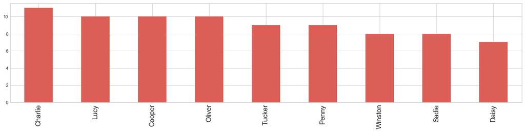

```python
ax=df_clean.dog_name.value_counts()[0:9].plot(kind='bar',figsize=(20,4))
ax.tick_params(axis='x',labelsize=15)
```

### 博主发布tweeter最常用的source

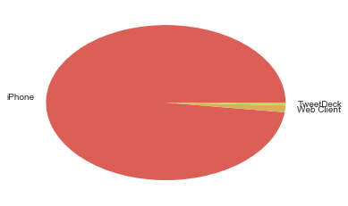

```python
fig=df_clean.source.value_counts()
plt.pie(fig, labels=fig.index)
```

### 最多点赞

```python
df_clean[df_clean.fav_count==df_clean.fav_count.max()]
```

|  | tweet_id | timestamp | source | text | expanded_urls | fav_count | retweet_count | jpg_url | breed | conf | pre_dog | stage | rating | dog_name |
| --- | --- | --- | --- | --- | --- | --- | --- | --- | --- | --- | --- | --- | --- | --- |
| 413 | 822872901745569793 | 2017-01-21 18:26:02 | iPhone | Here's a super supportive puppo participating ... | https://twitter.com/dog_rates/status/822872901... | 132318 | 47958 | https://pbs.twimg.com/media/C2tugXLXgAArJO4.jpg | Lakeland_terrier | 0.196015 | True | puppo | 1.3 | NaN |

```python
df_clean[df_clean.fav_count==132318].jpg_url
```

```
413    https://pbs.twimg.com/media/C2tugXLXgAArJO4.jpg
Name: jpg_url, dtype: object
```

```python
df_clean.text[413]
```

```
"Here's a super supportive puppo participating in the Toronto  #WomensMarch today. 13/10 https://t.co/nTz3FtorBc"
```

[figure not shown]

### 最多转发

```python
df_clean[df_clean.retweet_count==df_clean.retweet_count.max()]
```

|  | tweet_id | timestamp | source | text | expanded_urls | fav_count | retweet_count | jpg_url | breed | conf | pre_dog | stage | rating | dog_name |
| --- | --- | --- | --- | --- | --- | --- | --- | --- | --- | --- | --- | --- | --- | --- |
| 1039 | 744234799360020481 | 2016-06-18 18:26:18 | iPhone | Here's a doggo realizing you can stand in a po... | https://twitter.com/dog_rates/status/744234799... | 130533 | 79116 | https://pbs.twimg.com/ext_tw_video_thumb/74423... | Labrador_retriever | 0.825333 | True | doggo | 1.3 | NaN |

```python
print(df_clean.jpg_url[1039])
print(df_clean.text[1039])
```

```
https://pbs.twimg.com/ext_tw_video_thumb/744234667679821824/pu/img/1GaWmtJtdqzZV7jy.jpg
Here's a doggo realizing you can stand in a pool. 13/10 enlightened af (vid by Tina Conrad) https://t.co/7wE9LTEXC4
```

[figure not shown]

### 对比点赞数和转发数

```
[(0, 150000)]
```

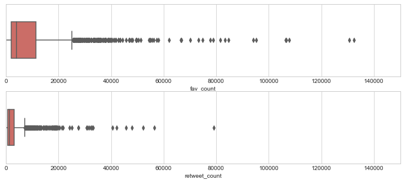

```python
fig =plt.figure(figsize=(12,5))
ax1=fig.add_subplot(211)
sns.boxplot(x=df_clean.fav_count,data=df_clean,width=0.5).set(xlim=(0,150000))
ax2=fig.add_subplot(212)
sns.boxplot(x=df_clean.retweet_count,data=df_clean,width=0.5).set(xlim=(0,150000))
```

### 博主评级最高的狗狗

```python
df_clean[df_clean.rating==df_clean.rating.max()]
```

|  | tweet_id | timestamp | source | text | expanded_urls | fav_count | retweet_count | jpg_url | breed | conf | pre_dog | stage | rating | dog_name |
| --- | --- | --- | --- | --- | --- | --- | --- | --- | --- | --- | --- | --- | --- | --- |
| 979 | 749981277374128128 | 2016-07-04 15:00:45 | TweetDeck | This is Atticus. He's quite simply America af.... | https://twitter.com/dog_rates/status/749981277... | 5594 | 2769 | https://pbs.twimg.com/media/CmgBZ7kWcAAlzFD.jpg | bow_tie | 0.533941 | False | NaN | 177.6 | Atticus |

```python
df_clean.text[979]
```

```
"This is Atticus. He's quite simply America af. 1776/10 https://t.co/GRXwMxLBkh"
```

最高得分高达177.6分，但机器对图片的预测认为图片上并不是狗（pre_dog=False）。下面是根据jpg_url查看原图得到的确认，原来是一只系领结的爱国狗，也是这个原因导致机器识别为bow_tie。

[figure not shown]

### 推文中出现频率最高的品种

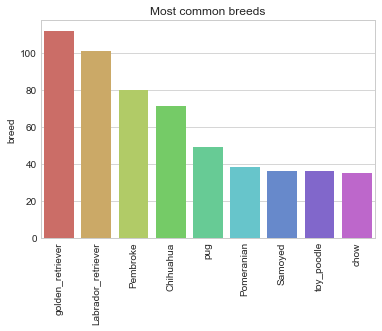

```python
ax=df_clean.breed.value_counts()[0:9]
fig=sns.barplot(x=ax.index,y=ax)
fig.set_title("Most common breeds")
plt.xticks(rotation=90)
```